# Mall Case Study

Rana Samir

10/01/2021

## Investigate the dataset

```r
summary(mall)
```

```
##    CustomerID        Gender               Age        Annual.Income..k..
##  Min.   :  1.00   Length:200         Min.   :18.00   Min.   : 15.00
##  1st Qu.: 50.75   Class :character   1st Qu.:28.75   1st Qu.: 41.50
##  Median :100.50   Mode  :character   Median :36.00   Median : 61.50
##  Mean   :100.50                      Mean   :38.85   Mean   : 60.56
##  3rd Qu.:150.25                      3rd Qu.:49.00   3rd Qu.: 78.00
##  Max.   :200.00                      Max.   :70.00   Max.   :137.00
##  Spending.Score..1.100.
##  Min.   : 1.00
##  1st Qu.:34.75
##  Median :50.00
##  Mean   :50.20
##  3rd Qu.:73.00
##  Max.   :99.00
```

```r
str(mall)
```

```
## 'data.frame':    200 obs. of  5 variables:
##  $ CustomerID            : int  1 2 3 4 5 6 7 8 9 10 ...
##  $ Gender                : chr  "Male" "Male" "Female" "Female" ...
##  $ Age                   : int  19 21 20 23 31 22 35 23 64 30 ...
##  $ Annual.Income..k..    : int  15 15 16 16 17 17 18 18 19 19 ...
##  $ Spending.Score..1.100.: int  39 81 6 77 40 76 6 94 3 72 ...
```

## Prepare the data for analysis

```r
# data preparation

#Normalize data
#normalize <- function(x) {return ((x - min(x)) / (max(x) - min(x)))}
#mall$Age=normalize(mall$Age)
#mall$Annual.Income..k..=normalize(mall$Annual.Income..k..)
#mall$Spending.Score..1.100.= normalize(mall$Spending.Score..1.100.)
#Remove unnecesser columns
mall$CustomerID=NULL
#Remove duplicates
mall=unique(mall)
```

# Hierarchical Clustering

```r
#Start the Hirearichal clustring

#Compute distance
distances= dist(mall[2:4], method="euclidean")
clustermall= hclust(distances, method="ward.D")
```

## Plot The Dendogram

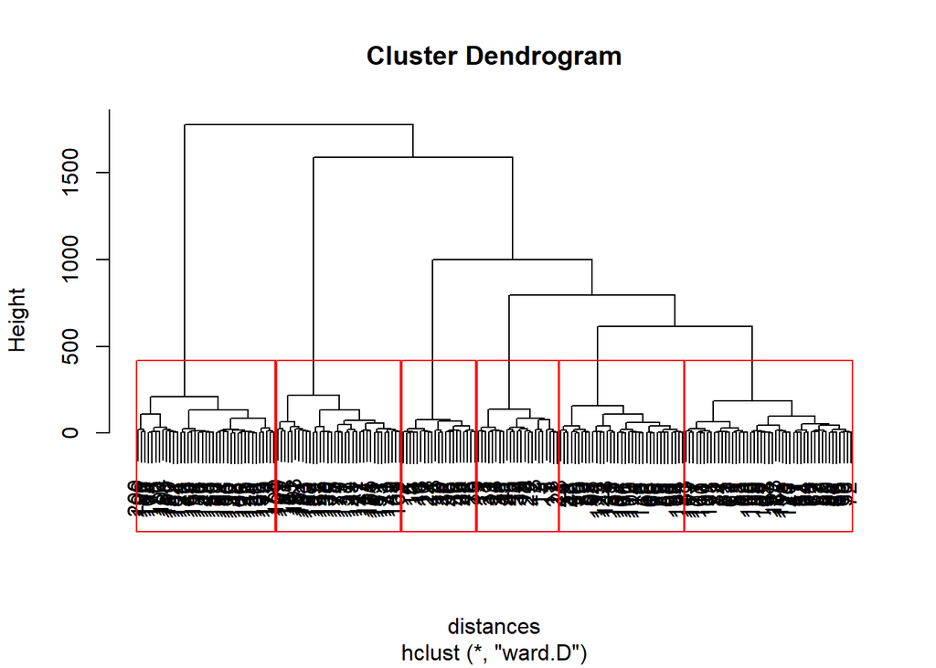

```r
#Assign clusters
clustegroups= cutree(clustermall, k=6)
#Invistigate the clusters
tapply(mall$Age, clustegroups, mean)
```

```
##        1        2        3        4        5        6
## 45.21739 24.80952 25.97143 54.59574 32.69231 41.68571
```

```r
tapply(mall$Annual.Income..k.., clustegroups, mean)
```

```
##        1        2        3        4        5        6
## 26.30435 25.61905 55.60000 54.46809 86.53846 88.22857
```

```r
tapply(mall$Spending.Score..1.100., clustegroups, mean)
```

```
##        1        2        3        4        5        6
## 20.91304 80.23810 48.77143 50.19149 82.12821 17.28571
```

### Cluster #1 charachterstics

```r
G1 = subset(mall, clustegroups==1)
G1
```

|  | Gender | Age | Annual.Income..k.. | Spending.Score..1.100. |
| --- | --- | --- | --- | --- |
| 1 | Male | 19 | 15 | 39 |
| 3 | Female | 20 | 16 | 6 |
| 5 | Female | 31 | 17 | 40 |
| 7 | Female | 35 | 18 | 6 |
| 9 | Male | 64 | 19 | 3 |
| 11 | Male | 67 | 19 | 14 |
| 13 | Female | 58 | 20 | 15 |
| 15 | Male | 37 | 20 | 13 |
| 17 | Female | 35 | 21 | 35 |
| 19 | Male | 52 | 23 | 29 |

[output cut: 13 more lines]

Show G1 summary

```r
summary(G1)
```

```
##     Gender               Age        Annual.Income..k.. Spending.Score..1.100.
##  Length:23          Min.   :19.00   Min.   :15.0       Min.   : 3.00
##  Class :character   1st Qu.:35.50   1st Qu.:19.5       1st Qu.: 9.50
##  Mode  :character   Median :46.00   Median :25.0       Median :17.00
##                     Mean   :45.22   Mean   :26.3       Mean   :20.91
##                     3rd Qu.:53.50   3rd Qu.:33.0       3rd Qu.:33.50
##                     Max.   :67.00   Max.   :39.0       Max.   :40.00
```

```r
table(G1$Gender)
```

```
##
## Female   Male
##     14      9
```

Spending score is low

However, both spending score and annual income are small. The mean value of age in this cluster is 45, however this cluster have a various ages in it resulting in a high range of ages within the cluster.

### Cluster #2 charachterstics

```r
G2 = subset(mall, clustegroups==2)
G2
```

|  | Gender | Age | Annual.Income..k.. | Spending.Score..1.100. |
| --- | --- | --- | --- | --- |
| 2 | Male | 21 | 15 | 81 |
| 4 | Female | 23 | 16 | 77 |
| 6 | Female | 22 | 17 | 76 |
| 8 | Female | 23 | 18 | 94 |
| 10 | Female | 30 | 19 | 72 |
| 12 | Female | 35 | 19 | 99 |
| 14 | Female | 24 | 20 | 77 |
| 16 | Male | 22 | 20 | 79 |
| 18 | Male | 20 | 21 | 66 |
| 20 | Female | 35 | 23 | 98 |

[output cut: 11 more lines]

```r
summary(G2)
```

```
##     Gender               Age        Annual.Income..k.. Spending.Score..1.100.
##  Length:21          Min.   :18.00   Min.   :15.00      Min.   :65.00
##  Class :character   1st Qu.:21.00   1st Qu.:19.00      1st Qu.:73.00
##  Mode  :character   Median :23.00   Median :24.00      Median :77.00
##                     Mean   :24.81   Mean   :25.62      Mean   :80.24
##                     3rd Qu.:29.00   3rd Qu.:33.00      3rd Qu.:87.00
##                     Max.   :35.00   Max.   :39.00      Max.   :99.00
```

```r
table(G2$Gender)
```

```
##
## Female   Male
##     13      8
```

Spending score is High

Howeever, both spending score and annual income are small. The mean value of age in this cluster is between 25-35 age group. And females is more than 60% of the cluster

### Cluster #3 charachterstics

```r
G3 = subset(mall, clustegroups==3)
G3
```

|  | Gender | Age | Annual.Income..k.. | Spending.Score..1.100. |
| --- | --- | --- | --- | --- |
| 28 | Male | 35 | 28 | 61 |
| 44 | Female | 31 | 39 | 61 |
| 48 | Female | 27 | 40 | 47 |
| 49 | Female | 29 | 40 | 42 |
| 50 | Female | 31 | 40 | 42 |
| 52 | Male | 33 | 42 | 60 |
| 53 | Female | 31 | 43 | 54 |
| 59 | Female | 27 | 46 | 51 |
| 62 | Male | 19 | 46 | 55 |
| 66 | Male | 18 | 48 | 59 |

[output cut: 25 more lines]

```r
summary(G3)
```

```
##     Gender               Age        Annual.Income..k.. Spending.Score..1.100.
##  Length:35          Min.   :18.00   Min.   :28.0       Min.   :29.00
##  Class :character   1st Qu.:20.50   1st Qu.:47.0       1st Qu.:42.00
##  Mode  :character   Median :26.00   Median :60.0       Median :50.00
##                     Mean   :25.97   Mean   :55.6       Mean   :48.77
##                     3rd Qu.:31.00   3rd Qu.:63.5       3rd Qu.:55.00
##                     Max.   :40.00   Max.   :76.0       Max.   :61.00
```

```r
table(G3$Gender)
```

```
##
## Female   Male
##     23     12
```

Spending score is Average

This cluster have a low spending score relative to its annual income. The mean value of age in this cluster is 25, however this cluster have a various ages in it resulting in a high range of ages within the cluster.

Females is two times more than males

```r
G4 = subset(mall, clustegroups==4)
G4
```

|  | Gender | Age | Annual.Income..k.. | Spending.Score..1.100. |
| --- | --- | --- | --- | --- |
| 47 | Female | 50 | 40 | 55 |
| 51 | Female | 49 | 42 | 52 |
| 54 | Male | 59 | 43 | 60 |
| 55 | Female | 50 | 43 | 45 |
| 56 | Male | 47 | 43 | 41 |
| 57 | Female | 51 | 44 | 50 |
| 58 | Male | 69 | 44 | 46 |
| 60 | Male | 53 | 46 | 46 |
| 61 | Male | 70 | 46 | 56 |
| 63 | Female | 67 | 47 | 52 |

[output cut: 37 more lines]

```r
summary(G4)
```

```
##     Gender               Age       Annual.Income..k.. Spending.Score..1.100.
##  Length:47          Min.   :34.0   Min.   :40.00      Min.   :41.00
##  Class :character   1st Qu.:48.0   1st Qu.:48.00      1st Qu.:46.00
##  Mode  :character   Median :51.0   Median :54.00      Median :50.00
##                     Mean   :54.6   Mean   :54.47      Mean   :50.19
##                     3rd Qu.:64.0   3rd Qu.:62.00      3rd Qu.:55.00
##                     Max.   :70.0   Max.   :69.00      Max.   :60.00
```

```r
table(G4$Gender)
```

```
##
## Female   Male
##     26     21
```

Spending score is Average

Females is slightly higher than males

```r
G5 = subset(mall, clustegroups==5)
G5
```

|  | Gender | Age | Annual.Income..k.. | Spending.Score..1.100. |
| --- | --- | --- | --- | --- |
| 124 | Male | 39 | 69 | 91 |
| 126 | Female | 31 | 70 | 77 |
| 128 | Male | 40 | 71 | 95 |
| 130 | Male | 38 | 71 | 75 |
| 132 | Male | 39 | 71 | 75 |
| 134 | Female | 31 | 72 | 71 |
| 136 | Female | 29 | 73 | 88 |
| 138 | Male | 32 | 73 | 73 |
| 140 | Female | 35 | 74 | 72 |
| 142 | Male | 32 | 75 | 93 |

[output cut: 29 more lines]

```r
summary(G5)
```

```
##     Gender               Age        Annual.Income..k.. Spending.Score..1.100.
##  Length:39          Min.   :27.00   Min.   : 69.00     Min.   :63.00
##  Class :character   1st Qu.:30.00   1st Qu.: 75.50     1st Qu.:74.50
##  Mode  :character   Median :32.00   Median : 79.00     Median :83.00
##                     Mean   :32.69   Mean   : 86.54     Mean   :82.13
##                     3rd Qu.:35.50   3rd Qu.: 95.00     3rd Qu.:90.00
##                     Max.   :40.00   Max.   :137.00     Max.   :97.00
```

```r
table(G5$Gender)
```

```
##
## Female   Male
##     21     18
```

Spending score is high

Annual Income is high

This cluster have a high spending score as well as high annual income The mean value of age in this cluster is 32, with no high variability in the age range

Females to males ration is negligable

```r
G6 = subset(mall, clustegroups==6)
G6
```

|  | Gender | Age | Annual.Income..k.. | Spending.Score..1.100. |
| --- | --- | --- | --- | --- |
| 127 | Male | 43 | 71 | 35 |
| 129 | Male | 59 | 71 | 11 |
| 131 | Male | 47 | 71 | 9 |
| 135 | Male | 20 | 73 | 5 |
| 137 | Female | 44 | 73 | 7 |
| 139 | Male | 19 | 74 | 10 |
| 141 | Female | 57 | 75 | 5 |
| 145 | Male | 25 | 77 | 12 |
| 147 | Male | 48 | 77 | 36 |
| 149 | Female | 34 | 78 | 22 |

[output cut: 25 more lines]

```r
summary(G6)
```

```
##     Gender               Age        Annual.Income..k.. Spending.Score..1.100.
##  Length:35          Min.   :19.00   Min.   : 71.00     Min.   : 1.00
##  Class :character   1st Qu.:35.00   1st Qu.: 77.50     1st Qu.:10.00
##  Mode  :character   Median :43.00   Median : 85.00     Median :16.00
##                     Mean   :41.69   Mean   : 88.23     Mean   :17.29
##                     3rd Qu.:47.50   3rd Qu.: 97.50     3rd Qu.:23.50
##                     Max.   :59.00   Max.   :137.00     Max.   :39.00
```

```r
table(G6$Gender)
```

```
##
## Female   Male
##     15     20
```

Spending score is low

Annual Income is high

This cluster have a low spending score vs a annual income. The mean value of age in this cluster is 41, however this cluster have a various ages in it resulting in a high range of ages within the cluster.

This is the only cluster that has males higher than femals.

# K-Means Clustring

```r
# Run k-means
k=5
set.seed(1)
KMC = kmeans(mall[2:4], centers = k, iter.max = 1000)
str(KMC)
```

```
## List of 9
##  $ cluster     : Named int [1:200] 3 5 3 5 3 5 3 5 3 5 ...
##   ..- attr(*, "names")= chr [1:200] "1" "2" "3" "4" ...
##  $ centers     : num [1:5, 1:3] 53.7 40.4 44.1 32.7 24.8 ...
##   ..- attr(*, "dimnames")=List of 2
##   .. ..$ : chr [1:5] "1" "2" "3" "4" ...
##   .. ..$ : chr [1:3] "Age" "Annual.Income..k.." "Spending.Score..1.100."
##  $ totss       : num 308813
##  $ withinss    : num [1:5] 11056 18994 7732 13972 27507
##  $ tot.withinss: num 79261
##  $ betweenss   : num 229552
##  $ size        : int [1:5] 52 38 21 39 50
##  $ iter        : int 3
##  $ ifault      : int 0
##  - attr(*, "class")= chr "kmeans"
```

```r
MallClusters = KMC$cluster
#Determine best number of clusters
KMC1 = kmeans(mall[2:4], centers = 2, iter.max = 1000)
KMC2 = kmeans(mall[2:4], centers = 3, iter.max = 1000)
KMC3 = kmeans(mall[2:4], centers = 4, iter.max = 1000)
KMC4 = kmeans(mall[2:4], centers = 5, iter.max = 1000)
KMC5 = kmeans(mall[2:4], centers = 6, iter.max = 1000)
KMC6 = kmeans(mall[2:4], centers = 7, iter.max = 1000)
KMC7 = kmeans(mall[2:4], centers = 8, iter.max = 1000)
KMC8 = kmeans(mall[2:4], centers = 9, iter.max = 1000)
KMC9 = kmeans(mall[2:4], centers = 10, iter.max = 1000)
```

### elbow method

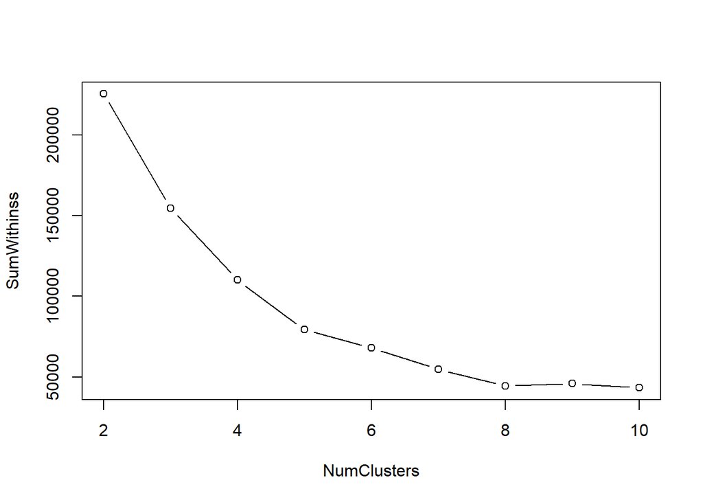

*5 is the best number of cluster*

### Clusters

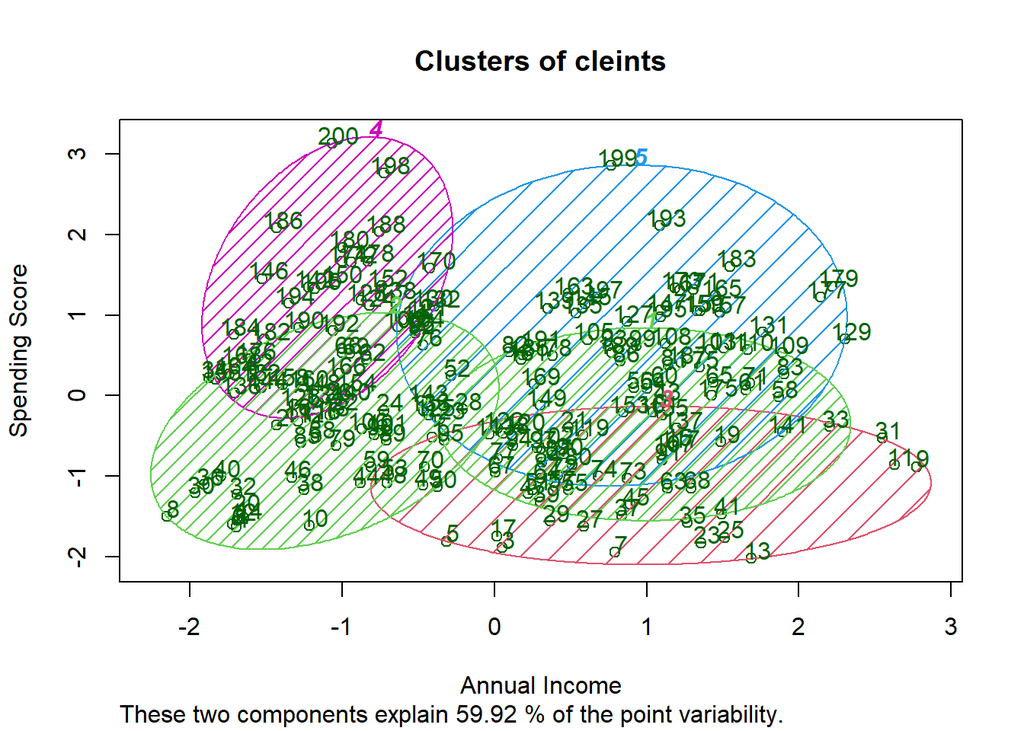

```r
aggregate(mall, by=list(cluster=KMC4$cluster), mean)
```

| cluster | Gender | Age | Annual.Income..k.. | Spending.Score..1.100. |
| --- | --- | --- | --- | --- |
| 1 | NA | 53.71154 | 54.42308 | 48.73077 |
| 2 | NA | 24.80000 | 41.46000 | 63.70000 |
| 3 | NA | 44.14286 | 25.14286 | 19.52381 |
| 4 | NA | 32.69231 | 86.53846 | 82.12821 |
| 5 | NA | 40.39474 | 87.00000 | 18.63158 |

```r
KMC4$size
```

```
## [1] 52 50 21 39 38
```

# Conclusion

**For the Hierarchical clustring**

Clusters 5,6 have the highest income. Clusters, 1,2 have the lowest income, and the other two clusters, 3,4 have an average income.

The spending score of these clusters is not proportional to their income. As the highest spending score clusters are 2,5, and the lowest spending score was given to people in cluster 6.

The notable trend in the data was that the high spending score was in the clusters of ages between 25-35 with a low variability within the cluster, like 2,5. The 40s age groups are all have a low spending score.

**For the K-Means clustring**

The results of the K-Means clustring wasn’t very different from the Hierarchical clustring. The most high spending cluster is 4, the least spending clusters are 3,5, and the last cluaters,1,2, have an average spending score. The trend deduced from the data are the same as the last one. the high spending score is associated with the younger age groups. and the 40s clusters have a low spending score. So the recomendation will be to target the clusters of the average spending and other than the 40s age, and target clusters with a high dispertion in age means. As mentioned the averge spending score clusers are 1,2 which have a mean age values of 25 and 54.

There were no big effect on the conclusion due to the change in the number of clusters between Hierarchical and k-means methods. Even in the number of recommended clusters to be targtted, there are no significant difference in the number of people in both clusters. However, I think the 6 clusters will be more accurate in the targetting campigns. So the following recommendations will be based on the Hierarchical.

# Summary and Recommendation

- Clusters 3,4 with average income and average spending score can be easily converge, so they should be targetted by advertising campaigns.
- Cluster 2 with low income but high spending score should be given a speical offers to make sure they stay loyal to the brand.
- Cluster 5 with the highest spending score and high income, should be targetted periodically, as they have more tendency to spend more in the brand.
- Cluster 1,6 have a low spending score although their distinct income values, they should be given a offers for free stuff to try the brands in order to make an acquisition.